# Behavior of Cyclistic Members vs Casual Riders

Jung Huh

8/7/2021

## Business Task

### Questions to answer

How do annual members and casual riders use Cyclistic bikes differently?

### Task Statement

Find differences in behaviors and annual members and casual riders and provide insights on how Cyclystic can convert the casual riders into annual members

Stakeholders: Marketing Analytics Team, Director of Marketing

## Data Sources

### Data Details

- Data Source: Company Cloud Database ([link](https://divvy-tripdata.s3.amazonaws.com/index.html))
  - Reliable? Yes
  - Original? Yes
  - Comprehensive? Yes
  - Current? Yes
  - Cited? Yes
- Currently, data is organized by each month.
- Data has been made available by this [license](https://www.divvybikes.com/data-license-agreement)
- Categorization of Member vs Casual
  - Single rides & Full day purchases are logged under Casual
  - Annual membership purcahses are logged under Member

## Cleaning and Preparing Data

### Importing Data

#### Install packages

```r
library(readr)
library(tidyverse)
library(lubridate)
library(ggplot2)
library(scales)
library(data.table)
```

#### Collect data

```r
setwd("C:/Users/Albert/Desktop/Cyclistic_Data/CSV")

Jun_2021 <- read_csv("202106-divvy-tripdata.csv")
May_2021 <- read_csv("202105-divvy-tripdata.csv")
Apr_2021 <- read_csv("202104-divvy-tripdata.csv")
Mar_2021 <- read_csv("202103-divvy-tripdata.csv")
Feb_2021 <- read_csv("202102-divvy-tripdata.csv")
Jan_2021 <- read_csv("202101-divvy-tripdata.csv")
Dec_2020 <- read_csv("202012-divvy-tripdata.csv")
Nov_2020 <- read_csv("202011-divvy-tripdata.csv")
Oct_2020 <- read_csv("202010-divvy-tripdata.csv")
Sep_2020 <- read_csv("202009-divvy-tripdata.csv")
Aug_2020 <- read_csv("202008-divvy-tripdata.csv")
Jul_2020 <- read_csv("202007-divvy-tripdata.csv")
```

### Cleaning and Preparing Data

#### Inspecting column to combine data into a single dataframe

- Extracting column names from latest monthly data and comparing it to rest using check_columns function
- check_columns function
  - returns "Matching Columns’ if column names match
  - returns "Mismatching Columns’ if column names do **not** match

```r
print(colnames(Jun_2021))
```

```
##  [1] "ride_id"            "rideable_type"      "started_at"
##  [4] "ended_at"           "start_station_name" "start_station_id"
##  [7] "end_station_name"   "end_station_id"     "start_lat"
## [10] "start_lng"          "end_lat"            "end_lng"
## [13] "member_casual"
```

```r
column_names <- colnames(Jun_2021)

check_columns <- function(monthlydata){
  if (column_names != colnames(monthlydata)){
    print('Mismatching Columns')
  } else {
    print('Mathcing Columns')
  }
}

check_columns(May_2021)
```

```
## [1] "Mathcing Columns"
```

```r
check_columns(Apr_2021)
```

```
## [1] "Mathcing Columns"
```

```r
check_columns(Mar_2021)
```

```
## [1] "Mathcing Columns"
```

```r
check_columns(Feb_2021)
```

```
## [1] "Mathcing Columns"
```

```r
check_columns(Jan_2021)
```

```
## [1] "Mathcing Columns"
```

```r
check_columns(Dec_2020)
```

```
## [1] "Mathcing Columns"
```

```r
check_columns(Nov_2020)
```

```
## [1] "Mathcing Columns"
```

```r
check_columns(Oct_2020)
```

```
## [1] "Mathcing Columns"
```

```r
check_columns(Sep_2020)
```

```
## [1] "Mathcing Columns"
```

```r
check_columns(Aug_2020)
```

```
## [1] "Mathcing Columns"
```

```r
check_columns(Jul_2020)
```

```
## [1] "Mathcing Columns"
```

#### Inspecting column attribute types

```r
str(Jun_2021)
```

```
## spec_tbl_df [729,595 x 13] (S3: spec_tbl_df/tbl_df/tbl/data.frame)
##  $ ride_id           : chr [1:729595] "99FEC93BA843FB20" "06048DCFC8520CAF" "9598066F68045DF2" "B03C0FE48C412214" ...
##  $ rideable_type     : chr [1:729595] "electric_bike" "electric_bike" "electric_bike" "electric_bike" ...
##  $ started_at        : POSIXct[1:729595], format: "2021-06-13 14:31:28" "2021-06-04 11:18:02" ...
##  $ ended_at          : POSIXct[1:729595], format: "2021-06-13 14:34:11" "2021-06-04 11:24:19" ...
##  $ start_station_name: chr [1:729595] NA NA NA NA ...
##  $ start_station_id  : chr [1:729595] NA NA NA NA ...
##  $ end_station_name  : chr [1:729595] NA NA NA NA ...
##  $ end_station_id    : chr [1:729595] NA NA NA NA ...
##  $ start_lat         : num [1:729595] 41.8 41.8 41.8 41.8 41.8 ...
##  $ start_lng         : num [1:729595] -87.6 -87.6 -87.6 -87.6 -87.6 ...
##  $ end_lat           : num [1:729595] 41.8 41.8 41.8 41.8 41.8 ...
##  $ end_lng           : num [1:729595] -87.6 -87.6 -87.6 -87.6 -87.6 ...
##  $ member_casual     : chr [1:729595] "member" "member" "member" "member" ...
##  - attr(*, "spec")=
##   .. cols(
##   ..   ride_id = col_character(),
##   ..   rideable_type = col_character(),
##   ..   started_at = col_datetime(format = ""),
##   ..   ended_at = col_datetime(format = ""),
##   ..   start_station_name = col_character(),
##   ..   start_station_id = col_character(),
##   ..   end_station_name = col_character(),
##   ..   end_station_id = col_character(),
##   ..   start_lat = col_double(),
##   ..   start_lng = col_double(),
##   ..   end_lat = col_double(),
##   ..   end_lng = col_double(),
##   ..   member_casual = col_character()
##   .. )
##  - attr(*, "problems")=<externalptr>
```

```r
str(May_2021)
```

```
## spec_tbl_df [531,633 x 13] (S3: spec_tbl_df/tbl_df/tbl/data.frame)
##  $ ride_id           : chr [1:531633] "C809ED75D6160B2A" "DD59FDCE0ACACAF3" "0AB83CB88C43EFC2" "7881AC6D39110C60" ...
##  $ rideable_type     : chr [1:531633] "electric_bike" "electric_bike" "electric_bike" "electric_bike" ...
##  $ started_at        : POSIXct[1:531633], format: "2021-05-30 11:58:15" "2021-05-30 11:29:14" ...
##  $ ended_at          : POSIXct[1:531633], format: "2021-05-30 12:10:39" "2021-05-30 12:14:09" ...
##  $ start_station_name: chr [1:531633] NA NA NA NA ...
##  $ start_station_id  : chr [1:531633] NA NA NA NA ...
##  $ end_station_name  : chr [1:531633] NA NA NA NA ...
##  $ end_station_id    : chr [1:531633] NA NA NA NA ...
##  $ start_lat         : num [1:531633] 41.9 41.9 41.9 41.9 41.9 ...
##  $ start_lng         : num [1:531633] -87.6 -87.6 -87.7 -87.7 -87.7 ...
##  $ end_lat           : num [1:531633] 41.9 41.8 41.9 41.9 41.9 ...
##  $ end_lng           : num [1:531633] -87.6 -87.6 -87.7 -87.7 -87.7 ...
##  $ member_casual     : chr [1:531633] "casual" "casual" "casual" "casual" ...
##  - attr(*, "spec")=
##   .. cols(
##   ..   ride_id = col_character(),
##   ..   rideable_type = col_character(),
##   ..   started_at = col_datetime(format = ""),
##   ..   ended_at = col_datetime(format = ""),
##   ..   start_station_name = col_character(),
##   ..   start_station_id = col_character(),
##   ..   end_station_name = col_character(),
##   ..   end_station_id = col_character(),
##   ..   start_lat = col_double(),
##   ..   start_lng = col_double(),
##   ..   end_lat = col_double(),
##   ..   end_lng = col_double(),
##   ..   member_casual = col_character()
##   .. )
##  - attr(*, "problems")=<externalptr>
```

```r
str(Apr_2021)
```

```
## spec_tbl_df [337,230 x 13] (S3: spec_tbl_df/tbl_df/tbl/data.frame)
##  $ ride_id           : chr [1:337230] "6C992BD37A98A63F" "1E0145613A209000" "E498E15508A80BAD" "1887262AD101C604" ...
##  $ rideable_type     : chr [1:337230] "classic_bike" "docked_bike" "docked_bike" "classic_bike" ...
##  $ started_at        : POSIXct[1:337230], format: "2021-04-12 18:25:36" "2021-04-27 17:27:11" ...
##  $ ended_at          : POSIXct[1:337230], format: "2021-04-12 18:56:55" "2021-04-27 18:31:29" ...
##  $ start_station_name: chr [1:337230] "State St & Pearson St" "Dorchester Ave & 49th St" "Loomis Blvd & 84th St" "Honore St & Division St" ...
##  $ start_station_id  : chr [1:337230] "TA1307000061" "KA1503000069" "20121" "TA1305000034" ...
##  $ end_station_name  : chr [1:337230] "Southport Ave & Waveland Ave" "Dorchester Ave & 49th St" "Loomis Blvd & 84th St" "Southport Ave & Waveland Ave" ...
##  $ end_station_id    : chr [1:337230] "13235" "KA1503000069" "20121" "13235" ...
##  $ start_lat         : num [1:337230] 41.9 41.8 41.7 41.9 41.7 ...
##  $ start_lng         : num [1:337230] -87.6 -87.6 -87.7 -87.7 -87.7 ...
##  $ end_lat           : num [1:337230] 41.9 41.8 41.7 41.9 41.7 ...
##  $ end_lng           : num [1:337230] -87.7 -87.6 -87.7 -87.7 -87.7 ...
##  $ member_casual     : chr [1:337230] "member" "casual" "casual" "member" ...
##  - attr(*, "spec")=
##   .. cols(
##   ..   ride_id = col_character(),
##   ..   rideable_type = col_character(),
##   ..   started_at = col_datetime(format = ""),
##   ..   ended_at = col_datetime(format = ""),
##   ..   start_station_name = col_character(),
##   ..   start_station_id = col_character(),
##   ..   end_station_name = col_character(),
##   ..   end_station_id = col_character(),
##   ..   start_lat = col_double(),
##   ..   start_lng = col_double(),
##   ..   end_lat = col_double(),
##   ..   end_lng = col_double(),
##   ..   member_casual = col_character()
##   .. )
##  - attr(*, "problems")=<externalptr>
```

```r
str(Mar_2021)
```

```
## spec_tbl_df [228,496 x 13] (S3: spec_tbl_df/tbl_df/tbl/data.frame)
##  $ ride_id           : chr [1:228496] "CFA86D4455AA1030" "30D9DC61227D1AF3" "846D87A15682A284" "994D05AA75A168F2" ...
##  $ rideable_type     : chr [1:228496] "classic_bike" "classic_bike" "classic_bike" "classic_bike" ...
##  $ started_at        : POSIXct[1:228496], format: "2021-03-16 08:32:30" "2021-03-28 01:26:28" ...
##  $ ended_at          : POSIXct[1:228496], format: "2021-03-16 08:36:34" "2021-03-28 01:36:55" ...
##  $ start_station_name: chr [1:228496] "Humboldt Blvd & Armitage Ave" "Humboldt Blvd & Armitage Ave" "Shields Ave & 28th Pl" "Winthrop Ave & Lawrence Ave" ...
##  $ start_station_id  : chr [1:228496] "15651" "15651" "15443" "TA1308000021" ...
##  $ end_station_name  : chr [1:228496] "Stave St & Armitage Ave" "Central Park Ave & Bloomingdale Ave" "Halsted St & 35th St" "Broadway & Sheridan Rd" ...
##  $ end_station_id    : chr [1:228496] "13266" "18017" "TA1308000043" "13323" ...
##  $ start_lat         : num [1:228496] 41.9 41.9 41.8 42 42 ...
##  $ start_lng         : num [1:228496] -87.7 -87.7 -87.6 -87.7 -87.7 ...
##  $ end_lat           : num [1:228496] 41.9 41.9 41.8 42 42.1 ...
##  $ end_lng           : num [1:228496] -87.7 -87.7 -87.6 -87.6 -87.7 ...
##  $ member_casual     : chr [1:228496] "casual" "casual" "casual" "casual" ...
##  - attr(*, "spec")=
##   .. cols(
##   ..   ride_id = col_character(),
##   ..   rideable_type = col_character(),
##   ..   started_at = col_datetime(format = ""),
##   ..   ended_at = col_datetime(format = ""),
##   ..   start_station_name = col_character(),
##   ..   start_station_id = col_character(),
##   ..   end_station_name = col_character(),
##   ..   end_station_id = col_character(),
##   ..   start_lat = col_double(),
##   ..   start_lng = col_double(),
##   ..   end_lat = col_double(),
##   ..   end_lng = col_double(),
##   ..   member_casual = col_character()
##   .. )
##  - attr(*, "problems")=<externalptr>
```

```r
str(Feb_2021)
```

```
## spec_tbl_df [49,622 x 13] (S3: spec_tbl_df/tbl_df/tbl/data.frame)
##  $ ride_id           : chr [1:49622] "89E7AA6C29227EFF" "0FEFDE2603568365" "E6159D746B2DBB91" "B32D3199F1C2E75B" ...
##  $ rideable_type     : chr [1:49622] "classic_bike" "classic_bike" "electric_bike" "classic_bike" ...
##  $ started_at        : POSIXct[1:49622], format: "2021-02-12 16:14:56" "2021-02-14 17:52:38" ...
##  $ ended_at          : POSIXct[1:49622], format: "2021-02-12 16:21:43" "2021-02-14 18:12:09" ...
##  $ start_station_name: chr [1:49622] "Glenwood Ave & Touhy Ave" "Glenwood Ave & Touhy Ave" "Clark St & Lake St" "Wood St & Chicago Ave" ...
##  $ start_station_id  : chr [1:49622] "525" "525" "KA1503000012" "637" ...
##  $ end_station_name  : chr [1:49622] "Sheridan Rd & Columbia Ave" "Bosworth Ave & Howard St" "State St & Randolph St" "Honore St & Division St" ...
##  $ end_station_id    : chr [1:49622] "660" "16806" "TA1305000029" "TA1305000034" ...
##  $ start_lat         : num [1:49622] 42 42 41.9 41.9 41.8 ...
##  $ start_lng         : num [1:49622] -87.7 -87.7 -87.6 -87.7 -87.6 ...
##  $ end_lat           : num [1:49622] 42 42 41.9 41.9 41.8 ...
##  $ end_lng           : num [1:49622] -87.7 -87.7 -87.6 -87.7 -87.6 ...
##  $ member_casual     : chr [1:49622] "member" "casual" "member" "member" ...
##  - attr(*, "spec")=
##   .. cols(
##   ..   ride_id = col_character(),
##   ..   rideable_type = col_character(),
##   ..   started_at = col_datetime(format = ""),
##   ..   ended_at = col_datetime(format = ""),
##   ..   start_station_name = col_character(),
##   ..   start_station_id = col_character(),
##   ..   end_station_name = col_character(),
##   ..   end_station_id = col_character(),
##   ..   start_lat = col_double(),
##   ..   start_lng = col_double(),
##   ..   end_lat = col_double(),
##   ..   end_lng = col_double(),
##   ..   member_casual = col_character()
##   .. )
##  - attr(*, "problems")=<externalptr>
```

```r
str(Jan_2021)
```

```
## spec_tbl_df [96,834 x 13] (S3: spec_tbl_df/tbl_df/tbl/data.frame)
##  $ ride_id           : chr [1:96834] "E19E6F1B8D4C42ED" "DC88F20C2C55F27F" "EC45C94683FE3F27" "4FA453A75AE377DB" ...
##  $ rideable_type     : chr [1:96834] "electric_bike" "electric_bike" "electric_bike" "electric_bike" ...
##  $ started_at        : POSIXct[1:96834], format: "2021-01-23 16:14:19" "2021-01-27 18:43:08" ...
##  $ ended_at          : POSIXct[1:96834], format: "2021-01-23 16:24:44" "2021-01-27 18:47:12" ...
##  $ start_station_name: chr [1:96834] "California Ave & Cortez St" "California Ave & Cortez St" "California Ave & Cortez St" "California Ave & Cortez St" ...
##  $ start_station_id  : chr [1:96834] "17660" "17660" "17660" "17660" ...
##  $ end_station_name  : chr [1:96834] NA NA NA NA ...
##  $ end_station_id    : chr [1:96834] NA NA NA NA ...
##  $ start_lat         : num [1:96834] 41.9 41.9 41.9 41.9 41.9 ...
##  $ start_lng         : num [1:96834] -87.7 -87.7 -87.7 -87.7 -87.7 ...
##  $ end_lat           : num [1:96834] 41.9 41.9 41.9 41.9 41.9 ...
##  $ end_lng           : num [1:96834] -87.7 -87.7 -87.7 -87.7 -87.7 ...
##  $ member_casual     : chr [1:96834] "member" "member" "member" "member" ...
##  - attr(*, "spec")=
##   .. cols(
##   ..   ride_id = col_character(),
##   ..   rideable_type = col_character(),
##   ..   started_at = col_datetime(format = ""),
##   ..   ended_at = col_datetime(format = ""),
##   ..   start_station_name = col_character(),
##   ..   start_station_id = col_character(),
##   ..   end_station_name = col_character(),
##   ..   end_station_id = col_character(),
##   ..   start_lat = col_double(),
##   ..   start_lng = col_double(),
##   ..   end_lat = col_double(),
##   ..   end_lng = col_double(),
##   ..   member_casual = col_character()
##   .. )
##  - attr(*, "problems")=<externalptr>
```

```r
str(Dec_2020)
```

```
## spec_tbl_df [131,573 x 13] (S3: spec_tbl_df/tbl_df/tbl/data.frame)
##  $ ride_id           : chr [1:131573] "70B6A9A437D4C30D" "158A465D4E74C54A" "5262016E0F1F2F9A" "BE119628E44F871E" ...
##  $ rideable_type     : chr [1:131573] "classic_bike" "electric_bike" "electric_bike" "electric_bike" ...
##  $ started_at        : POSIXct[1:131573], format: "2020-12-27 12:44:29" "2020-12-18 17:37:15" ...
##  $ ended_at          : POSIXct[1:131573], format: "2020-12-27 12:55:06" "2020-12-18 17:44:19" ...
##  $ start_station_name: chr [1:131573] "Aberdeen St & Jackson Blvd" NA NA NA ...
##  $ start_station_id  : chr [1:131573] "13157" NA NA NA ...
##  $ end_station_name  : chr [1:131573] "Desplaines St & Kinzie St" NA NA NA ...
##  $ end_station_id    : chr [1:131573] "TA1306000003" NA NA NA ...
##  $ start_lat         : num [1:131573] 41.9 41.9 41.9 41.9 41.8 ...
##  $ start_lng         : num [1:131573] -87.7 -87.7 -87.7 -87.7 -87.6 ...
##  $ end_lat           : num [1:131573] 41.9 41.9 41.9 41.9 41.8 ...
##  $ end_lng           : num [1:131573] -87.6 -87.7 -87.7 -87.7 -87.6 ...
##  $ member_casual     : chr [1:131573] "member" "member" "member" "member" ...
##  - attr(*, "spec")=
##   .. cols(
##   ..   ride_id = col_character(),
##   ..   rideable_type = col_character(),
##   ..   started_at = col_datetime(format = ""),
##   ..   ended_at = col_datetime(format = ""),
##   ..   start_station_name = col_character(),
##   ..   start_station_id = col_character(),
##   ..   end_station_name = col_character(),
##   ..   end_station_id = col_character(),
##   ..   start_lat = col_double(),
##   ..   start_lng = col_double(),
##   ..   end_lat = col_double(),
##   ..   end_lng = col_double(),
##   ..   member_casual = col_character()
##   .. )
##  - attr(*, "problems")=<externalptr>
```

```r
str(Nov_2020)
```

```
## spec_tbl_df [259,716 x 13] (S3: spec_tbl_df/tbl_df/tbl/data.frame)
##  $ ride_id           : chr [1:259716] "BD0A6FF6FFF9B921" "96A7A7A4BDE4F82D" "C61526D06582BDC5" "E533E89C32080B9E" ...
##  $ rideable_type     : chr [1:259716] "electric_bike" "electric_bike" "electric_bike" "electric_bike" ...
##  $ started_at        : POSIXct[1:259716], format: "2020-11-01 13:36:00" "2020-11-01 10:03:26" ...
##  $ ended_at          : POSIXct[1:259716], format: "2020-11-01 13:45:40" "2020-11-01 10:14:45" ...
##  $ start_station_name: chr [1:259716] "Dearborn St & Erie St" "Franklin St & Illinois St" "Lake Shore Dr & Monroe St" "Leavitt St & Chicago Ave" ...
##  $ start_station_id  : num [1:259716] 110 672 76 659 2 72 76 NA 58 394 ...
##  $ end_station_name  : chr [1:259716] "St. Clair St & Erie St" "Noble St & Milwaukee Ave" "Federal St & Polk St" "Stave St & Armitage Ave" ...
##  $ end_station_id    : num [1:259716] 211 29 41 185 2 76 72 NA 288 273 ...
##  $ start_lat         : num [1:259716] 41.9 41.9 41.9 41.9 41.9 ...
##  $ start_lng         : num [1:259716] -87.6 -87.6 -87.6 -87.7 -87.6 ...
##  $ end_lat           : num [1:259716] 41.9 41.9 41.9 41.9 41.9 ...
##  $ end_lng           : num [1:259716] -87.6 -87.7 -87.6 -87.7 -87.6 ...
##  $ member_casual     : chr [1:259716] "casual" "casual" "casual" "casual" ...
##  - attr(*, "spec")=
##   .. cols(
##   ..   ride_id = col_character(),
##   ..   rideable_type = col_character(),
##   ..   started_at = col_datetime(format = ""),
##   ..   ended_at = col_datetime(format = ""),
##   ..   start_station_name = col_character(),
##   ..   start_station_id = col_double(),
##   ..   end_station_name = col_character(),
##   ..   end_station_id = col_double(),
##   ..   start_lat = col_double(),
##   ..   start_lng = col_double(),
##   ..   end_lat = col_double(),
##   ..   end_lng = col_double(),
##   ..   member_casual = col_character()
##   .. )
##  - attr(*, "problems")=<externalptr>
```

```r
str(Oct_2020)
```

```
## spec_tbl_df [388,653 x 13] (S3: spec_tbl_df/tbl_df/tbl/data.frame)
##  $ ride_id           : chr [1:388653] "ACB6B40CF5B9044C" "DF450C72FD109C01" "B6396B54A15AC0DF" "44A4AEE261B9E854" ...
##  $ rideable_type     : chr [1:388653] "electric_bike" "electric_bike" "electric_bike" "electric_bike" ...
##  $ started_at        : POSIXct[1:388653], format: "2020-10-31 19:39:43" "2020-10-31 23:50:08" ...
##  $ ended_at          : POSIXct[1:388653], format: "2020-10-31 19:57:12" "2020-11-01 00:04:16" ...
##  $ start_station_name: chr [1:388653] "Lakeview Ave & Fullerton Pkwy" "Southport Ave & Waveland Ave" "Stony Island Ave & 67th St" "Clark St & Grace St" ...
##  $ start_station_id  : num [1:388653] 313 227 102 165 190 359 313 125 NA 174 ...
##  $ end_station_name  : chr [1:388653] "Rush St & Hubbard St" "Kedzie Ave & Milwaukee Ave" "University Ave & 57th St" "Broadway & Sheridan Rd" ...
##  $ end_station_id    : num [1:388653] 125 260 423 256 185 53 125 313 199 635 ...
##  $ start_lat         : num [1:388653] 41.9 41.9 41.8 42 41.9 ...
##  $ start_lng         : num [1:388653] -87.6 -87.7 -87.6 -87.7 -87.7 ...
##  $ end_lat           : num [1:388653] 41.9 41.9 41.8 42 41.9 ...
##  $ end_lng           : num [1:388653] -87.6 -87.7 -87.6 -87.7 -87.7 ...
##  $ member_casual     : chr [1:388653] "casual" "casual" "casual" "casual" ...
##  - attr(*, "spec")=
##   .. cols(
##   ..   ride_id = col_character(),
##   ..   rideable_type = col_character(),
##   ..   started_at = col_datetime(format = ""),
##   ..   ended_at = col_datetime(format = ""),
##   ..   start_station_name = col_character(),
##   ..   start_station_id = col_double(),
##   ..   end_station_name = col_character(),
##   ..   end_station_id = col_double(),
##   ..   start_lat = col_double(),
##   ..   start_lng = col_double(),
##   ..   end_lat = col_double(),
##   ..   end_lng = col_double(),
##   ..   member_casual = col_character()
##   .. )
##  - attr(*, "problems")=<externalptr>
```

```r
str(Sep_2020)
```

```
## spec_tbl_df [532,958 x 13] (S3: spec_tbl_df/tbl_df/tbl/data.frame)
##  $ ride_id           : chr [1:532958] "2B22BD5F95FB2629" "A7FB70B4AFC6CAF2" "86057FA01BAC778E" "57F6DC9A153DB98C" ...
##  $ rideable_type     : chr [1:532958] "electric_bike" "electric_bike" "electric_bike" "electric_bike" ...
##  $ started_at        : POSIXct[1:532958], format: "2020-09-17 14:27:11" "2020-09-17 15:07:31" ...
##  $ ended_at          : POSIXct[1:532958], format: "2020-09-17 14:44:24" "2020-09-17 15:07:45" ...
##  $ start_station_name: chr [1:532958] "Michigan Ave & Lake St" "W Oakdale Ave & N Broadway" "W Oakdale Ave & N Broadway" "Ashland Ave & Belle Plaine Ave" ...
##  $ start_station_id  : num [1:532958] 52 NA NA 246 24 94 291 NA NA NA ...
##  $ end_station_name  : chr [1:532958] "Green St & Randolph St" "W Oakdale Ave & N Broadway" "W Oakdale Ave & N Broadway" "Montrose Harbor" ...
##  $ end_station_id    : num [1:532958] 112 NA NA 249 24 NA 256 NA NA NA ...
##  $ start_lat         : num [1:532958] 41.9 41.9 41.9 42 41.9 ...
##  $ start_lng         : num [1:532958] -87.6 -87.6 -87.6 -87.7 -87.6 ...
##  $ end_lat           : num [1:532958] 41.9 41.9 41.9 42 41.9 ...
##  $ end_lng           : num [1:532958] -87.6 -87.6 -87.6 -87.6 -87.6 ...
##  $ member_casual     : chr [1:532958] "casual" "casual" "casual" "casual" ...
##  - attr(*, "spec")=
##   .. cols(
##   ..   ride_id = col_character(),
##   ..   rideable_type = col_character(),
##   ..   started_at = col_datetime(format = ""),
##   ..   ended_at = col_datetime(format = ""),
##   ..   start_station_name = col_character(),
##   ..   start_station_id = col_double(),
##   ..   end_station_name = col_character(),
##   ..   end_station_id = col_double(),
##   ..   start_lat = col_double(),
##   ..   start_lng = col_double(),
##   ..   end_lat = col_double(),
##   ..   end_lng = col_double(),
##   ..   member_casual = col_character()
##   .. )
##  - attr(*, "problems")=<externalptr>
```

```r
str(Aug_2020)
```

```
## spec_tbl_df [622,361 x 13] (S3: spec_tbl_df/tbl_df/tbl/data.frame)
##  $ ride_id           : chr [1:622361] "322BD23D287743ED" "2A3AEF1AB9054D8B" "67DC1D133E8B5816" "C79FBBD412E578A7" ...
##  $ rideable_type     : chr [1:622361] "docked_bike" "electric_bike" "electric_bike" "electric_bike" ...
##  $ started_at        : POSIXct[1:622361], format: "2020-08-20 18:08:14" "2020-08-27 18:46:04" ...
##  $ ended_at          : POSIXct[1:622361], format: "2020-08-20 18:17:51" "2020-08-27 19:54:51" ...
##  $ start_station_name: chr [1:622361] "Lake Shore Dr & Diversey Pkwy" "Michigan Ave & 14th St" "Columbus Dr & Randolph St" "Daley Center Plaza" ...
##  $ start_station_id  : num [1:622361] 329 168 195 81 658 658 196 67 153 177 ...
##  $ end_station_name  : chr [1:622361] "Clark St & Lincoln Ave" "Michigan Ave & 14th St" "State St & Randolph St" "State St & Kinzie St" ...
##  $ end_station_id    : num [1:622361] 141 168 44 47 658 658 49 229 225 305 ...
##  $ start_lat         : num [1:622361] 41.9 41.9 41.9 41.9 41.9 ...
##  $ start_lng         : num [1:622361] -87.6 -87.6 -87.6 -87.6 -87.7 ...
##  $ end_lat           : num [1:622361] 41.9 41.9 41.9 41.9 41.9 ...
##  $ end_lng           : num [1:622361] -87.6 -87.6 -87.6 -87.6 -87.7 ...
##  $ member_casual     : chr [1:622361] "member" "casual" "casual" "casual" ...
##  - attr(*, "spec")=
##   .. cols(
##   ..   ride_id = col_character(),
##   ..   rideable_type = col_character(),
##   ..   started_at = col_datetime(format = ""),
##   ..   ended_at = col_datetime(format = ""),
##   ..   start_station_name = col_character(),
##   ..   start_station_id = col_double(),
##   ..   end_station_name = col_character(),
##   ..   end_station_id = col_double(),
##   ..   start_lat = col_double(),
##   ..   start_lng = col_double(),
##   ..   end_lat = col_double(),
##   ..   end_lng = col_double(),
##   ..   member_casual = col_character()
##   .. )
##  - attr(*, "problems")=<externalptr>
```

```r
str(Jul_2020)
```

```
## spec_tbl_df [551,480 x 13] (S3: spec_tbl_df/tbl_df/tbl/data.frame)
##  $ ride_id           : chr [1:551480] "762198876D69004D" "BEC9C9FBA0D4CF1B" "D2FD8EA432C77EC1" "54AE594E20B35881" ...
##  $ rideable_type     : chr [1:551480] "docked_bike" "docked_bike" "docked_bike" "docked_bike" ...
##  $ started_at        : POSIXct[1:551480], format: "2020-07-09 15:22:02" "2020-07-24 23:56:30" ...
##  $ ended_at          : POSIXct[1:551480], format: "2020-07-09 15:25:52" "2020-07-25 00:20:17" ...
##  $ start_station_name: chr [1:551480] "Ritchie Ct & Banks St" "Halsted St & Roscoe St" "Lake Shore Dr & Diversey Pkwy" "LaSalle St & Illinois St" ...
##  $ start_station_id  : num [1:551480] 180 299 329 181 268 635 113 211 176 31 ...
##  $ end_station_name  : chr [1:551480] "Wells St & Evergreen Ave" "Broadway & Ridge Ave" "Clark St & Wellington Ave" "Clark St & Armitage Ave" ...
##  $ end_station_id    : num [1:551480] 291 461 156 94 301 289 140 31 191 142 ...
##  $ start_lat         : num [1:551480] 41.9 41.9 41.9 41.9 41.9 ...
##  $ start_lng         : num [1:551480] -87.6 -87.6 -87.6 -87.6 -87.6 ...
##  $ end_lat           : num [1:551480] 41.9 42 41.9 41.9 41.9 ...
##  $ end_lng           : num [1:551480] -87.6 -87.7 -87.6 -87.6 -87.6 ...
##  $ member_casual     : chr [1:551480] "member" "member" "casual" "casual" ...
##  - attr(*, "spec")=
##   .. cols(
##   ..   ride_id = col_character(),
##   ..   rideable_type = col_character(),
##   ..   started_at = col_datetime(format = ""),
##   ..   ended_at = col_datetime(format = ""),
##   ..   start_station_name = col_character(),
##   ..   start_station_id = col_double(),
##   ..   end_station_name = col_character(),
##   ..   end_station_id = col_double(),
##   ..   start_lat = col_double(),
##   ..   start_lng = col_double(),
##   ..   end_lat = col_double(),
##   ..   end_lng = col_double(),
##   ..   member_casual = col_character()
##   .. )
##  - attr(*, "problems")=<externalptr>
```

- Found out that start_station_id and end_station_id are in different data types in Nov_2020 - Jun_2020

#### Stacking monthly data into a data frame

- Changing data types for congruency
- Creating a master data frame called oneYear_data

```r
Nov_2020 <- mutate(Nov_2020, start_station_id = as.character(start_station_id),
                   end_station_id = as.character(end_station_id))
Oct_2020 <- mutate(Oct_2020, start_station_id = as.character(start_station_id),
                   end_station_id = as.character(end_station_id))
Sep_2020 <- mutate(Sep_2020, start_station_id = as.character(start_station_id),
                   end_station_id = as.character(end_station_id))
Aug_2020 <- mutate(Aug_2020, start_station_id = as.character(start_station_id),
                   end_station_id = as.character(end_station_id))
Jul_2020 <- mutate(Jul_2020, start_station_id = as.character(start_station_id),
                   end_station_id = as.character(end_station_id))


oneYear_data <- bind_rows(Jun_2021, May_2021, Apr_2021, Mar_2021, Feb_2021, Jan_2021, Dec_2020, Nov_2020, Oct_2020, Sep_2020, Aug_2020, Jul_2020)
head(oneYear_data)
```

```
## # A tibble: 6 x 13
##   ride_id          rideable_type started_at          ended_at            start_station_n~
##   <chr>            <chr>         <dttm>              <dttm>              <chr>
## 1 99FEC93BA843FB20 electric_bike 2021-06-13 14:31:28 2021-06-13 14:34:11 <NA>
## 2 06048DCFC8520CAF electric_bike 2021-06-04 11:18:02 2021-06-04 11:24:19 <NA>
## 3 9598066F68045DF2 electric_bike 2021-06-04 09:49:35 2021-06-04 09:55:34 <NA>
## 4 B03C0FE48C412214 electric_bike 2021-06-03 19:56:05 2021-06-03 20:21:55 <NA>
## 5 B9EEA89F8FEE73B7 electric_bike 2021-06-04 14:05:51 2021-06-04 14:09:59 <NA>
## 6 62B943CEAAA420BA electric_bike 2021-06-03 19:32:01 2021-06-03 19:38:46 <NA>
## # ... with 8 more variables: start_station_id <chr>, end_station_name <chr>,
## #   end_station_id <chr>, start_lat <dbl>, start_lng <dbl>, end_lat <dbl>,
## #   end_lng <dbl>, member_casual <chr>
```

#### Checking for data consistency

- Checking for consistency in categorical columns

```r
table(oneYear_data$member_casual)
```

```
##
##  casual  member
## 1929319 2530832
```

```r
table(oneYear_data$rideable_type)
```

```
##
##  classic_bike   docked_bike electric_bike
##       1278605       2050197       1131349
```

#### Inspecting the new data table

```r
colnames(oneYear_data)
```

```
##  [1] "ride_id"            "rideable_type"      "started_at"
##  [4] "ended_at"           "start_station_name" "start_station_id"
##  [7] "end_station_name"   "end_station_id"     "start_lat"
## [10] "start_lng"          "end_lat"            "end_lng"
## [13] "member_casual"
```

```r
nrow(oneYear_data)
```

```
## [1] 4460151
```

```r
dim(oneYear_data)
```

```
## [1] 4460151      13
```

```r
head(oneYear_data)
```

```
## # A tibble: 6 x 13
##   ride_id          rideable_type started_at          ended_at            start_station_n~
##   <chr>            <chr>         <dttm>              <dttm>              <chr>
## 1 99FEC93BA843FB20 electric_bike 2021-06-13 14:31:28 2021-06-13 14:34:11 <NA>
## 2 06048DCFC8520CAF electric_bike 2021-06-04 11:18:02 2021-06-04 11:24:19 <NA>
## 3 9598066F68045DF2 electric_bike 2021-06-04 09:49:35 2021-06-04 09:55:34 <NA>
## 4 B03C0FE48C412214 electric_bike 2021-06-03 19:56:05 2021-06-03 20:21:55 <NA>
## 5 B9EEA89F8FEE73B7 electric_bike 2021-06-04 14:05:51 2021-06-04 14:09:59 <NA>
## 6 62B943CEAAA420BA electric_bike 2021-06-03 19:32:01 2021-06-03 19:38:46 <NA>
## # ... with 8 more variables: start_station_id <chr>, end_station_name <chr>,
## #   end_station_id <chr>, start_lat <dbl>, start_lng <dbl>, end_lat <dbl>,
## #   end_lng <dbl>, member_casual <chr>
```

```r
str(oneYear_data)
```

```
## spec_tbl_df [4,460,151 x 13] (S3: spec_tbl_df/tbl_df/tbl/data.frame)
##  $ ride_id           : chr [1:4460151] "99FEC93BA843FB20" "06048DCFC8520CAF" "9598066F68045DF2" "B03C0FE48C412214" ...
##  $ rideable_type     : chr [1:4460151] "electric_bike" "electric_bike" "electric_bike" "electric_bike" ...
##  $ started_at        : POSIXct[1:4460151], format: "2021-06-13 14:31:28" "2021-06-04 11:18:02" ...
##  $ ended_at          : POSIXct[1:4460151], format: "2021-06-13 14:34:11" "2021-06-04 11:24:19" ...
##  $ start_station_name: chr [1:4460151] NA NA NA NA ...
##  $ start_station_id  : chr [1:4460151] NA NA NA NA ...
##  $ end_station_name  : chr [1:4460151] NA NA NA NA ...
##  $ end_station_id    : chr [1:4460151] NA NA NA NA ...
##  $ start_lat         : num [1:4460151] 41.8 41.8 41.8 41.8 41.8 ...
##  $ start_lng         : num [1:4460151] -87.6 -87.6 -87.6 -87.6 -87.6 ...
##  $ end_lat           : num [1:4460151] 41.8 41.8 41.8 41.8 41.8 ...
##  $ end_lng           : num [1:4460151] -87.6 -87.6 -87.6 -87.6 -87.6 ...
##  $ member_casual     : chr [1:4460151] "member" "member" "member" "member" ...
##  - attr(*, "spec")=
##   .. cols(
##   ..   ride_id = col_character(),
##   ..   rideable_type = col_character(),
##   ..   started_at = col_datetime(format = ""),
##   ..   ended_at = col_datetime(format = ""),
##   ..   start_station_name = col_character(),
##   ..   start_station_id = col_character(),
##   ..   end_station_name = col_character(),
##   ..   end_station_id = col_character(),
##   ..   start_lat = col_double(),
##   ..   start_lng = col_double(),
##   ..   end_lat = col_double(),
##   ..   end_lng = col_double(),
##   ..   member_casual = col_character()
##   .. )
##  - attr(*, "problems")=<externalptr>
```

```r
summary(oneYear_data)
```

```
##    ride_id          rideable_type        started_at
##  Length:4460151     Length:4460151     Min.   :2020-07-01 00:00:14
##  Class :character   Class :character   1st Qu.:2020-08-29 14:06:10
##  Mode  :character   Mode  :character   Median :2020-11-11 11:51:43
##                                        Mean   :2020-12-25 05:10:09
##                                        3rd Qu.:2021-05-11 20:43:11
##                                        Max.   :2021-06-30 23:59:59
##
##     ended_at                   start_station_name start_station_id
##  Min.   :2020-07-01 00:03:01   Length:4460151     Length:4460151
##  1st Qu.:2020-08-29 14:35:14   Class :character   Class :character
##  Median :2020-11-11 12:08:21   Mode  :character   Mode  :character
##  Mean   :2020-12-25 05:33:58
##  3rd Qu.:2021-05-11 21:00:43
##  Max.   :2021-07-13 22:51:35
##
##  end_station_name   end_station_id       start_lat       start_lng
##  Length:4460151     Length:4460151     Min.   :41.64   Min.   :-87.87
##  Class :character   Class :character   1st Qu.:41.88   1st Qu.:-87.66
##  Mode  :character   Mode  :character   Median :41.90   Median :-87.64
##                                        Mean   :41.90   Mean   :-87.64
##                                        3rd Qu.:41.93   3rd Qu.:-87.63
##                                        Max.   :42.08   Max.   :-87.52
##
##     end_lat         end_lng       member_casual
##  Min.   :41.51   Min.   :-88.07   Length:4460151
##  1st Qu.:41.88   1st Qu.:-87.66   Class :character
##  Median :41.90   Median :-87.64   Mode  :character
##  Mean   :41.90   Mean   :-87.64
##  3rd Qu.:41.93   3rd Qu.:-87.63
##  Max.   :42.16   Max.   :-87.44
##  NA's   :5286    NA's   :5286
```

#### Adding new columns

##### Seprating day, month, year from started_at

```r
oneYear_data$date <- as.Date(oneYear_data$started_at)
oneYear_data$month <- format(as.Date(oneYear_data$date), '%m')
oneYear_data$day <- format(as.Date(oneYear_data$date), '%d')
oneYear_data$year <- format(as.Date(oneYear_data$date), '%Y')
oneYear_data$day_of_week <- format(as.Date(oneYear_data$date), '%A')
```

##### Adding ‘ride_duration’ column

```r
oneYear_data$ride_duration <- difftime(oneYear_data$ended_at, oneYear_data$started_at)
```

#### Removing ‘bad’ data

- Removing data with negative or zero (less than 1 second) ride_duration
  - Some rows had negative duration
  - After some research, we can conclude that these bikes were taken out of circulation for quality control

```r
negative_duration <- filter(oneYear_data, ride_duration < 1)
str(negative_duration)
```

```
## spec_tbl_df [10,352 x 19] (S3: spec_tbl_df/tbl_df/tbl/data.frame)
##  $ ride_id           : chr [1:10352] "732D84DAD2CC9B73" "9D5797261E298A08" "A18D39992AA99793" "BE185F3203C9B7E1" ...
##  $ rideable_type     : chr [1:10352] "classic_bike" "classic_bike" "classic_bike" "docked_bike" ...
##  $ started_at        : POSIXct[1:10352], format: "2021-06-20 10:52:26" "2021-06-30 16:39:51" ...
##  $ ended_at          : POSIXct[1:10352], format: "2021-06-20 10:52:25" "2021-06-30 16:39:51" ...
##  $ start_station_name: chr [1:10352] "Clinton St & Polk St" "Wallace St & 35th St" "Broadway & Sheridan Rd" "Broadway & Argyle St" ...
##  $ start_station_id  : chr [1:10352] "15542" "TA1308000045" "13323" "13108" ...
##  $ end_station_name  : chr [1:10352] "Clinton St & Polk St" "Wallace St & 35th St" "Broadway & Sheridan Rd" "Broadway & Argyle St" ...
##  $ end_station_id    : chr [1:10352] "15542" "TA1308000045" "13323" "13108" ...
##  $ start_lat         : num [1:10352] 41.9 41.8 42 42 41.9 ...
##  $ start_lng         : num [1:10352] -87.6 -87.6 -87.6 -87.7 -87.6 ...
##  $ end_lat           : num [1:10352] 41.9 41.8 42 42 41.9 ...
##  $ end_lng           : num [1:10352] -87.6 -87.6 -87.6 -87.7 -87.6 ...
##  $ member_casual     : chr [1:10352] "casual" "member" "casual" "casual" ...
##  $ date              : Date[1:10352], format: "2021-06-20" "2021-06-30" ...
##  $ month             : chr [1:10352] "06" "06" "06" "06" ...
##  $ day               : chr [1:10352] "20" "30" "15" "06" ...
##  $ year              : chr [1:10352] "2021" "2021" "2021" "2021" ...
##  $ day_of_week       : chr [1:10352] "Sunday" "Wednesday" "Tuesday" "Sunday" ...
##  $ ride_duration     : 'difftime' num [1:10352] -1 0 -192 0 ...
##   ..- attr(*, "units")= chr "secs"
##  - attr(*, "spec")=
##   .. cols(
##   ..   ride_id = col_character(),
##   ..   rideable_type = col_character(),
##   ..   started_at = col_datetime(format = ""),
##   ..   ended_at = col_datetime(format = ""),
##   ..   start_station_name = col_character(),
##   ..   start_station_id = col_character(),
##   ..   end_station_name = col_character(),
##   ..   end_station_id = col_character(),
##   ..   start_lat = col_double(),
##   ..   start_lng = col_double(),
##   ..   end_lat = col_double(),
##   ..   end_lng = col_double(),
##   ..   member_casual = col_character()
##   .. )
##  - attr(*, "problems")=<externalptr>
```

```r
nrow(negative_duration)
```

```
## [1] 10352
```

- Removing data with ride duration of one **day** and more
  - Upon reviewing company’s policy on bike rentals of more than 24 hours, bikes that have been rented for 24+ hours are treated as **stolen** or **missing**

```r
oneYear_data_V3 <-filter(oneYear_data, ride_duration >= 1 & ride_duration < 60*60*24)
nrow(oneYear_data_V3)
```

```
## [1] 4446235
```

- Removing data resulting from internal tests
  - Testing data are not relevant to the analysis

```r
nrow(subset(oneYear_data_V3, start_station_name %like% "TEST"))
```

```
## [1] 3069
```

```r
nrow(subset(oneYear_data_V3, start_station_name %like% "test"))
```

```
## [1] 3
```

```r
nrow(subset(oneYear_data_V3, start_station_name %like% "Test"))
```

```
## [1] 0
```

```r
oneYear_data_V4 <- filter(oneYear_data_V3, !(oneYear_data_V3$start_station_name %like% "TEST" | oneYear_data_V3$start_station_name %like% "test"))
nrow(oneYear_data_V4)
```

```
## [1] 4443163
```

## Analysis

### Taking a look at some statistical values

#### Average ride duration of Members vs Casuals

```r
aggregate(oneYear_data_V4$ride_duration ~ oneYear_data_V4$member_casual, FUN = mean)
```

```
##   oneYear_data_V4$member_casual oneYear_data_V4$ride_duration
## 1                        casual                1991.3611 secs
## 2                        member                 887.9292 secs
```

#### Median ride duration of Members vs Casuals

```r
aggregate(oneYear_data_V4$ride_duration ~ oneYear_data_V4$member_casual, FUN = median)
```

```
##   oneYear_data_V4$member_casual oneYear_data_V4$ride_duration
## 1                        casual                     1155 secs
## 2                        member                      648 secs
```

#### Max. and Min. ride duration of Members vc Casuals

```r
aggregate(oneYear_data_V4$ride_duration ~ oneYear_data_V4$member_casual, FUN = max)
```

```
##   oneYear_data_V4$member_casual oneYear_data_V4$ride_duration
## 1                        casual                    86394 secs
## 2                        member                    86383 secs
```

```r
aggregate(oneYear_data_V4$ride_duration ~ oneYear_data_V4$member_casual, FUN = min)
```

```
##   oneYear_data_V4$member_casual oneYear_data_V4$ride_duration
## 1                        casual                        1 secs
## 2                        member                        1 secs
```

```r
aggregate(oneYear_data_V4$ride_duration ~ oneYear_data_V4$member_casual, FUN = sd)
```

```
##   oneYear_data_V4$member_casual oneYear_data_V4$ride_duration
## 1                        casual                      3486.117
## 2                        member                      1302.706
```

#### Examining ride duration for a weekday for Members vs Casuals

```r
oneYear_data_V4$day_of_week <- ordered(oneYear_data_V4$day_of_week, levels = c("Sunday", "Monday", 'Tuesday', 'Wednesday', 'Thursday', 'Friday' , 'Saturday'))
aggregate(oneYear_data_V4$ride_duration ~ oneYear_data_V4$member_casual + oneYear_data_V4$day_of_week, FUN = mean)
```

```
##    oneYear_data_V4$member_casual oneYear_data_V4$day_of_week
## 1                         casual                      Sunday
## 2                         member                      Sunday
## 3                         casual                      Monday
## 4                         member                      Monday
## 5                         casual                     Tuesday
## 6                         member                     Tuesday
## 7                         casual                   Wednesday
## 8                         member                   Wednesday
## 9                         casual                    Thursday
## 10                        member                    Thursday
## 11                        casual                      Friday
## 12                        member                      Friday
## 13                        casual                    Saturday
## 14                        member                    Saturday
##    oneYear_data_V4$ride_duration
## 1                 2237.2258 secs
## 2                  993.9848 secs
## 3                 1966.0026 secs
## 4                  850.3924 secs
## 5                 1825.6164 secs
## 6                  840.9749 secs
## 7                 1757.6510 secs
## 8                  845.3476 secs
## 9                 1780.9154 secs
## 10                 839.9345 secs
## 11                1900.0425 secs
## 12                 876.8415 secs
## 13                2149.4063 secs
## 14                 977.3885 secs
```

#### Examining number of rides and ride duration for a weekday for Members vs Casuals

```r
oneYear_data_V4 %>%
  mutate(weekday = lubridate::wday(started_at, label = TRUE)) %>%
           group_by(member_casual, weekday) %>%
           summarise(number_of_rides = n(), average_duration = mean(ride_duration)) %>%
           arrange(member_casual, weekday)
```

```
## # A tibble: 14 x 4
## # Groups:   member_casual [2]
##    member_casual weekday number_of_rides average_duration
##    <chr>         <ord>             <int> <drtn>
##  1 casual        Sun              365265 2237.2258 secs
##  2 casual        Mon              208158 1966.0026 secs
##  3 casual        Tue              203025 1825.6164 secs
##  4 casual        Wed              214432 1757.6510 secs
##  5 casual        Thu              211326 1780.9154 secs
##  6 casual        Fri              279596 1900.0425 secs
##  7 casual        Sat              438122 2149.4063 secs
##  8 member        Sun              322423  993.9848 secs
##  9 member        Mon              336721  850.3924 secs
## 10 member        Tue              363508  840.9749 secs
## 11 member        Wed              388202  845.3476 secs
## 12 member        Thu              362984  839.9345 secs
## 13 member        Fri              373720  876.8415 secs
## 14 member        Sat              375681  977.3885 secs
```

## Data Viz and Key Fidings

### Members vs Casuals - Number of Rides each day of the Week

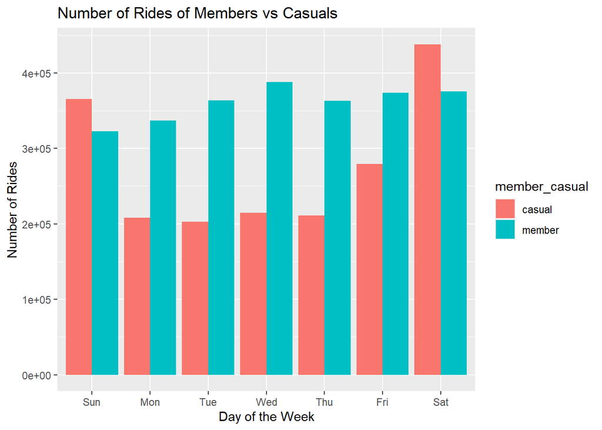

```r
oneYear_data_V4 %>%
  mutate(weekday = lubridate::wday(started_at, label = TRUE)) %>%
           group_by(member_casual, weekday) %>%
           summarise(number_of_rides = n(), average_duration = mean(ride_duration)) %>%
           arrange(member_casual, weekday) %>%
  ggplot(aes(x = weekday, y = number_of_rides, fill = member_casual)) +
  geom_col(position = "dodge") + xlab("Day of the Week") + ylab('Number of Rides') + ggtitle("Number of Rides of Members vs Casuals")
```

```r
ggsave('Number_of_Rides.png')
```

### Members vs Casuals - Average Ride Duration

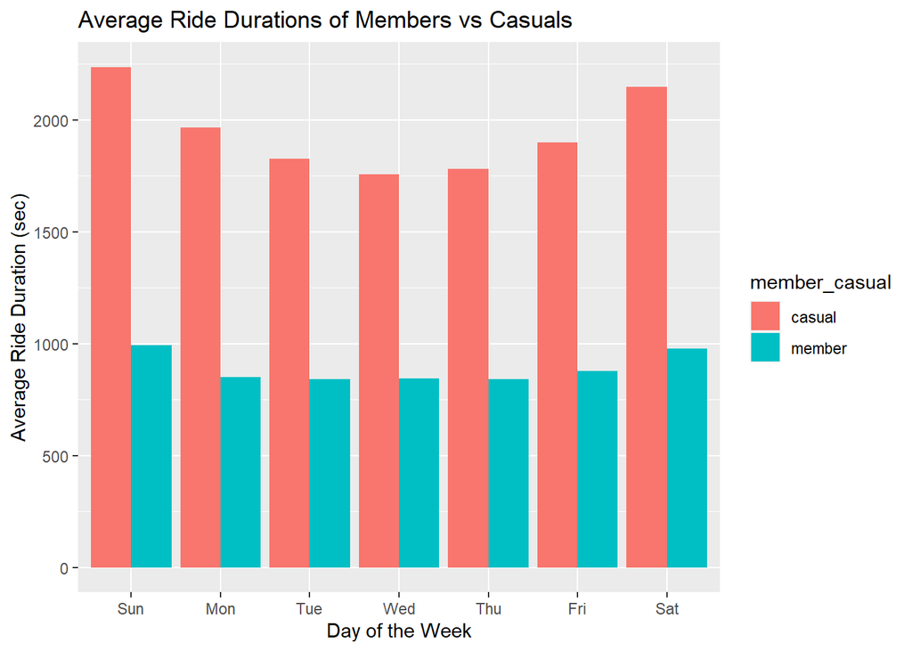

```r
oneYear_data_V4 %>%
  mutate(weekday = lubridate::wday(started_at, label = TRUE)) %>%
           group_by(member_casual, weekday) %>%
           summarise(number_of_rides = n(), average_duration = mean(ride_duration)) %>%
           arrange(member_casual, weekday) %>%
  ggplot(aes(x = weekday, y = average_duration, fill = member_casual)) +
  geom_col(position = "dodge") + xlab("Day of the Week") + ylab('Average Ride Duration (sec)') + ggtitle("Average Ride Durations of Members vs Casuals")
```

```r
ggsave('Average_Ride_Duration.png')
```

### Members vs Casuals - Number of Rides each Month

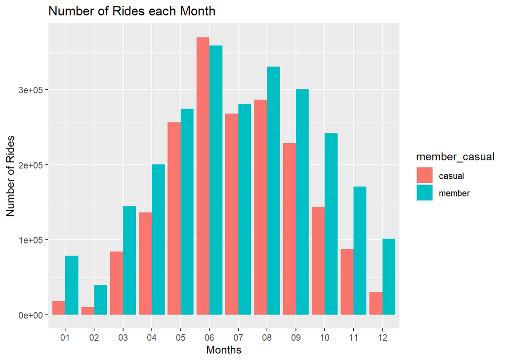

```r
oneYear_data_V4 %>%
  group_by(member_casual, month) %>%
  summarise(total_rides = n()) %>%
  ggplot(aes(x = month, y = total_rides, fill = member_casual)) +
  geom_col(position = 'dodge') + xlab("Months") +ylab("Number of Rides") +ggtitle("Number of Rides each Month")
```

### Members vs Casuals - Number of Rides by each Hour

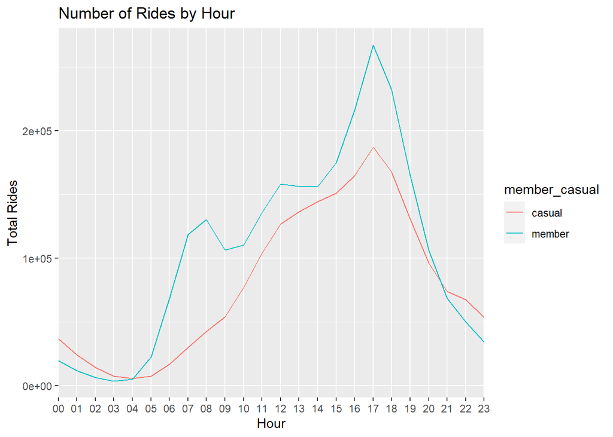

```r
oneYear_data_V4$time <- format(oneYear_data_V4$started_at, format = '%H:%M')
oneYear_data_V4$time <- as.POSIXct(oneYear_data_V4$time, format = '%H')
oneYear_data_V4 %>%
  group_by(member_casual, time) %>%
  summarise(total_rides = n()) %>%
  ggplot(aes(x = time, y = total_rides, color = member_casual, group = member_casual)) +
  geom_line() + scale_x_datetime(date_breaks = "1 hour", minor_breaks = NULL,
date_labels = "%H", expand = c(0,0)) + xlab('Hour') + ylab('Total Rides') +ggtitle("Number of Rides by Hour")
```

### Key Findings and Disclaimer

#### Key Findings

```r
nrow(subset(oneYear_data_V4, member_casual == 'casual' & (day_of_week == 'Friday' | day_of_week == 'Saturday' | day_of_week == 'Sunday'))) / nrow(subset(oneYear_data_V4, member_casual == 'casual'))
```

```
## [1] 0.564076
```

```r
nrow(subset(oneYear_data_V4, member_casual == 'casual' & (month == "06" | month == "07" | month == "08"))) / nrow(subset(oneYear_data_V4, member_casual == 'casual'))
```

```
## [1] 0.4815639
```

```r
nrow(subset(oneYear_data_V4, member_casual == 'member' & (month == "06" | month == "07" | month == "08"))) / nrow(subset(oneYear_data_V4, member_casual == 'member'))
```

```
## [1] 0.384673
```

#### Disclaimer

- Data Removal:
  - Data with negative ride duration were removed
  - Data with ride duration of greater than 24 hours were removed
- Possible Bias:
  - May have introduced sampling bias by removing rides where ride duration was negative or greater than 24 hours

## Recommendations

### Second

- Accommodate riders quicker in the morning rush hours
  - Biggest difference in number of rides between members and non-members are found during rush hours
  - Casual riders may opt out of riding a bike if it takes more than a minute or two to rent/find one
  - Consolidating the rental process during rush hours recommended

### Third

- Create a database with unique ID for each rider instead of each trip
  - It will enable deeper analysis on specific subsets of riders
  - Understanding characteristics of casual riders and their trips can provide valuable information that can be used in user conversion